# Homework 4

Thomas Billman

February 19, 2018

## Problem 4.22

We begin by constructing our dataset

```r
Prob422 = as.data.frame(matrix(rep(0,25*5), nrow = 25))
Prob422[,1] = 1:25
Prob422[,2] = c("A","B","D","C","E",
                "C","E","A","D","B",
                "B","A","C","E","D",
                "D","C","E","B","A",
                "E","D","B","A","C")
Prob422[,3] = gl(5,5)
Prob422[,4] = gl(5,1,25)
Prob422[,5] = c(8,7,1,7,3,
                11,2,7,3,8,
                4,9,10,1,5,
                6,8,6,6,10,
                4,2,3,8,8)
colnames(Prob422) = c("OBS","Ingredient", "Batch", "Day","Reaction.Time")
Prob422$Ingredient <- factor(Prob422$Ingredient)
Prob422$Batch <- factor(Prob422$Batch)
Prob422$Day <- factor(Prob422$Day)
Prob422
```

```
##    OBS Ingredient Batch Day Reaction.Time
## 1    1          A     1   1             8
## 2    2          B     1   2             7
## 3    3          D     1   3             1
## 4    4          C     1   4             7
## 5    5          E     1   5             3
## 6    6          C     2   1            11
## 7    7          E     2   2             2
## 8    8          A     2   3             7
## 9    9          D     2   4             3
## 10  10          B     2   5             8
## 11  11          B     3   1             4
## 12  12          A     3   2             9
## 13  13          C     3   3            10
## 14  14          E     3   4             1
## 15  15          D     3   5             5
## 16  16          D     4   1             6
## 17  17          C     4   2             8
## 18  18          E     4   3             6
## 19  19          B     4   4             6
## 20  20          A     4   5            10
## 21  21          E     5   1             4
## 22  22          D     5   2             2
## 23  23          B     5   3             3
## 24  24          A     5   4             8
## 25  25          C     5   5             8
```

### Analysis

```r
prob422.lm <- lm(Reaction.Time ~ Ingredient + Batch + Day, data = Prob422)
anova(prob422.lm)
```

```
## Analysis of Variance Table
##
## Response: Reaction.Time
##            Df Sum Sq Mean Sq F value    Pr(>F)
## Ingredient  4 141.44  35.360 11.3092 0.0004877 ***
## Batch       4  15.44   3.860  1.2345 0.3476182
## Day         4  12.24   3.060  0.9787 0.4550143
## Residuals  12  37.52   3.127
## ---
## Signif. codes:  0 '***' 0.001 '**' 0.01 '*' 0.05 '.' 0.1 ' ' 1
```

Given that the P value for ingredient is 4.876511810^{-4}, which is less than our $\alpha$ of .05. There for we reject our $H_o : \tau_A = \tau_B = \tau_C = \tau_D = \tau_E$ and infer that there exists at least one inequality amongst the treatment effects for ingredient.

### Assumption Checking

It is also worth checking to confirm that the assumptions behind this test are met by our data.

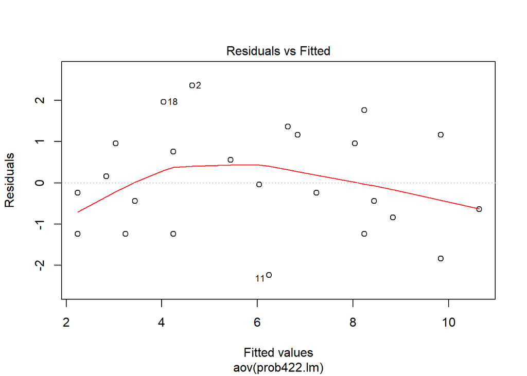

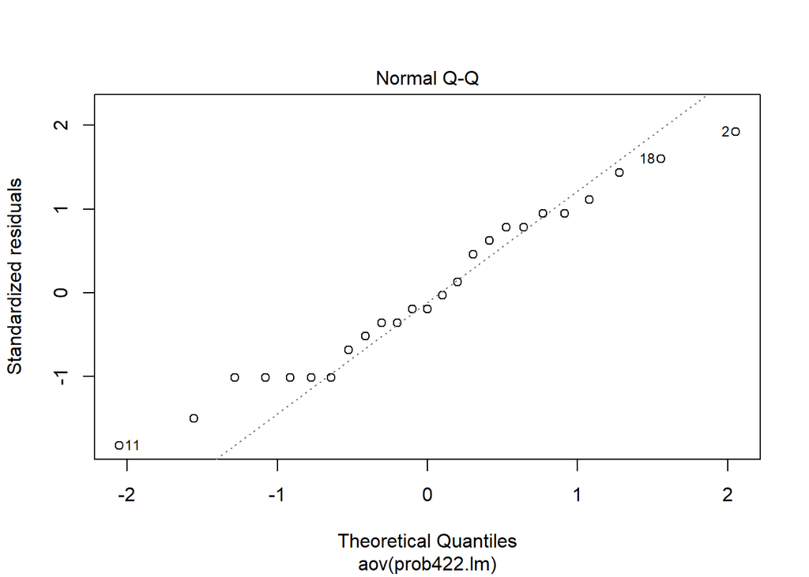

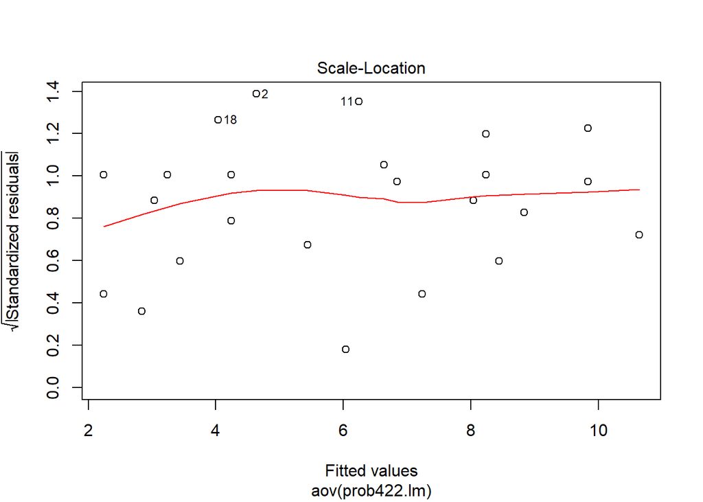

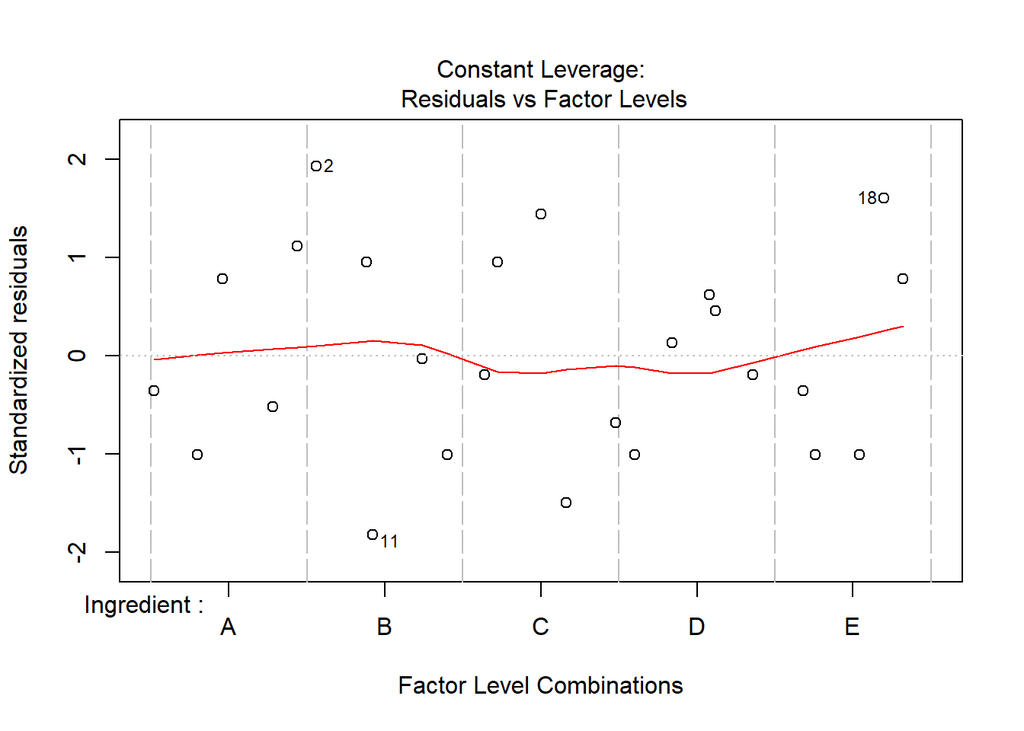

```r
plot(aov(prob422.lm))
```